# R Practice — Bias in Self-Reported Turnout (Solution)

Instructor solution

Quantitative Methods for Humanities. PPE 2nd Year - 2025-2026

> **Important**  
> 1) Fill in `student_id` below.  
> 2) Do **not** rename chunk labels (e.g., `ex1`, `ex2`, …).  
> 3) Your file must **Knit** (Compile) to HTML from a **clean session** (no manual steps).

# Introduction

Surveys are frequently used to measure political behavior such as voter turnout, but some researchers are concerned about the accuracy of self-reports. In particular, they worry about possible social desirability bias where, in postelection surveys, respondents who did not vote in an election lie about not having voted because they may feel that they should have voted. Is such a bias present in the American National Election Studies (ANES)?

# Data

The following table displays the names and descriptions of variables in the `turnout.csv` data file.

| Variable | Description |
| --- | --- |
| `year` | election year |
| `ANES` | ANES estimated turnout rate |
| `VEP` | voting eligible population (in thousands) |
| `VAP` | voting age population (in thousands) |
| `total` | total ballots cast for highest office (in thousands) |
| `felons` | total ineligible felons (in thousands) |
| `noncit` | total noncitizens (in thousands) |
| `overseas` | total eligible overseas voters (in thousands) |
| `osvoters` | total ballots counted by overseas voters (in thousands) |

## Exercise 1 - Data summary

**Tasks/Questions:**

1. Load the data into R and save it into a variable called `turnout`.
2. Check the dimensions.
3. Obtain a summary of the dataset.
4. Report: number of observations and range of years covered.

```r
# 1) Load
turnout <- read.csv("turnout.csv")

# 2) Dimensions
dim(turnout)
```

```
## [1] 14  9
```

```r
# 3) Summary
summary(turnout)
```

```
##       year           VEP              VAP             total
##  Min.   :1980   Min.   :159635   Min.   :164445   Min.   : 64991
##  1st Qu.:1986   1st Qu.:171192   1st Qu.:178930   1st Qu.: 73179
##  Median :1993   Median :181140   Median :193018   Median : 89055
##  Mean   :1993   Mean   :182640   Mean   :194226   Mean   : 89778
##  3rd Qu.:2000   3rd Qu.:193353   3rd Qu.:209296   3rd Qu.:102370
##  Max.   :2008   Max.   :213314   Max.   :230872   Max.   :131304
##
##       ANES           felons         noncit         overseas       osvoters
##  Min.   :47.00   Min.   : 802   Min.   : 5756   Min.   :1803   Min.   :263
##  1st Qu.:57.00   1st Qu.:1424   1st Qu.: 8592   1st Qu.:2236   1st Qu.:263
##  Median :70.50   Median :2312   Median :11972   Median :2458   Median :263
##  Mean   :65.79   Mean   :2177   Mean   :12229   Mean   :2746   Mean   :263
##  3rd Qu.:73.75   3rd Qu.:3042   3rd Qu.:15910   3rd Qu.:2937   3rd Qu.:263
##  Max.   :78.00   Max.   :3168   Max.   :19392   Max.   :4972   Max.   :263
##                                                                NA's   :13
```

```r
# 4) Key facts
n_obs <- nrow(turnout)
year_min <- min(turnout$year)
year_max <- max(turnout$year)

n_obs
```

```
## [1] 14
```

```r
c(year_min = year_min, year_max = year_max)
```

```
## year_min year_max
##     1980     2008
```

**Takeaways (example):**

- The dataset has **14** rows (one per election year) and covers **1980–2008**.
- The key quantities are turnout rates (`ANES`) and administrative counts (`VAP`, `VEP`, `total`, …).

# Analysis

## Exercise 2 — Turnout rate calculation (VAP and VEP)

**Tasks/Questions:**

1. Compute turnout based on **VAP**, adding eligible overseas voters to the denominator. Store it as `turnout$vap_turnout`.
2. Compute turnout based on **VEP**. Store it as `turnout$vep_turnout`.
3. Describe the difference you observe.

```r
# Turnout rates (ratios still work because everything is in thousands)
turnout$vap_turnout <- turnout$total / (turnout$VAP + turnout$overseas)
turnout$vep_turnout <- turnout$total / turnout$VEP

# A quick summary
mean_vap <- mean(turnout$vap_turnout, na.rm = TRUE)
mean_vep <- mean(turnout$vep_turnout, na.rm = TRUE)
mean_gap_vap_minus_vep <- mean(turnout$vap_turnout - turnout$vep_turnout, na.rm = TRUE)

c(mean_vap = mean_vap, mean_vep = mean_vep, mean_vap_minus_vep = mean_gap_vap_minus_vep)
```

```
##           mean_vap           mean_vep mean_vap_minus_vep
##         0.45456569         0.48949360        -0.03492792
```

```r
# Optional: look at the first few rows
head(turnout[, c("year","vap_turnout","vep_turnout")])
```

```
##   year vap_turnout vep_turnout
## 1 1980   0.5203970   0.5419551
## 2 1982   0.4024524   0.4213702
## 3 1984   0.5253746   0.5524858
## 4 1986   0.3607842   0.3814114
## 5 1988   0.4972259   0.5276845
## 6 1990   0.3593885   0.3841895
```

**Takeaways (example):**

- Average VAP-turnout ≈ **0.455**, average VEP-turnout ≈ **0.489**.
- The average difference (VAP − VEP) is **-0.035**.

**Interpretation (example):**  
VEP typically differs from VAP because it tries to remove people who are not eligible to vote (e.g., noncitizens, ineligible felons). That can change the denominator and therefore the turnout rate.

## Exercise 3 — Compare VAP vs ANES, and VEP vs ANES

**Tasks/Questions:**

1. Compute differences:
- `diff_vap_anes = vap_turnout - ANES`
- `diff_vep_anes = vep_turnout - ANES`
2. Report average difference and range.

```r
turnout$diff_vap_anes <- turnout$vap_turnout - turnout$ANES
turnout$diff_vep_anes <- turnout$vep_turnout - turnout$ANES

# Summary stats
mean_diff_vap <- mean(turnout$diff_vap_anes, na.rm = TRUE)
range_diff_vap <- range(turnout$diff_vap_anes, na.rm = TRUE)

mean_diff_vep <- mean(turnout$diff_vep_anes, na.rm = TRUE)
range_diff_vep <- range(turnout$diff_vep_anes, na.rm = TRUE)

list(
  vap_minus_anes_mean = mean_diff_vap,
  vap_minus_anes_range = range_diff_vap,
  vep_minus_anes_mean = mean_diff_vep,
  vep_minus_anes_range = range_diff_vep
)
```

```
## $vap_minus_anes_mean
## [1] -65.35258
##
## $vap_minus_anes_range
## [1] -77.04326 -46.44061
##
## $vep_minus_anes_mean
## [1] -65.31765
##
## $vep_minus_anes_range
## [1] -76.98446 -46.41581
```

**Takeaways (example):**

- Mean bias (VEP − ANES) is **-65.318**, ranging from **-76.984** to **-46.416**.
- Mean bias (VAP − ANES) is **-65.353**, ranging from **-77.043** to **-46.441**.

**Interpretation (example):**  
A **negative** value of (VEP − ANES) means ANES turnout is **higher** than administrative turnout; a **positive** value means ANES turnout is **lower**.

## Exercise 4 — Compare across election types (presidential vs midterm)

**Tasks/Questions:**

1. Create `turnout$election_type` (`presidential` if year is a multiple of 4; otherwise `midterm`).
2. Compare VEP turnout vs ANES separately by election type.

```r
turnout$election_type <- ifelse(turnout$year %% 4 == 0, "presidential", "midterm")

# Average bias by election type (using VEP - ANES)
bias_by_type <- tapply(turnout$diff_vep_anes, turnout$election_type, mean, na.rm = TRUE)
bias_by_type
```

```
##      midterm presidential
##    -54.65429    -73.31517
```

**Takeaways (example):**

- Mean bias in presidential years: **-73.315**
- Mean bias in midterm years: **-54.654**

**Interpretation (example):**  
If one election type has a systematically larger (more negative) bias, it suggests misreporting (or nonresponse) may differ depending on the type of election.

## Exercise 5 — Temporal bias trends (two periods)

**Tasks/Questions:**

1. Has the bias of ANES increased over time?
2. Is the time-evolution pattern the same for presidential vs midterm years?
3. Use `boxplot()` to visualize the differences.

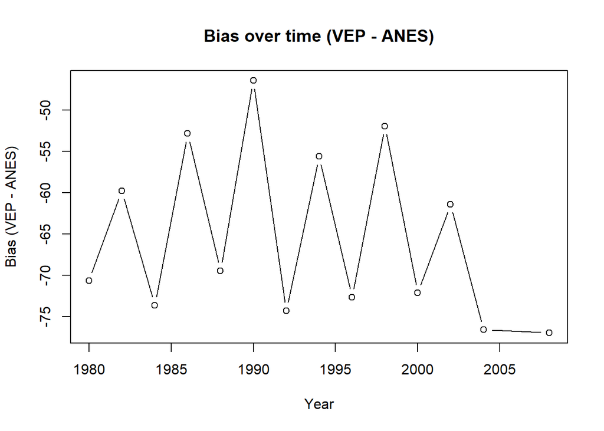

```r
# We'll define two periods (simple split). Any reasonable split is OK if stated clearly.
split_year <- 1980
turnout$period <- ifelse(turnout$year <= split_year, paste0("<= ", split_year), paste0("> ", split_year))

# (1) Bias over time: a simple time plot
plot(turnout$year, turnout$diff_vep_anes,
     type = "b",
     xlab = "Year",
     ylab = "Bias (VEP - ANES)",
     main = "Bias over time (VEP - ANES)")

abline(h = 0, lty = 2)
```

```r
# (2) Average bias by period
bias_by_period <- tapply(turnout$diff_vep_anes, turnout$period, mean, na.rm = TRUE)
bias_by_period
```

```
##   <= 1980    > 1980
## -70.65804 -64.90685
```

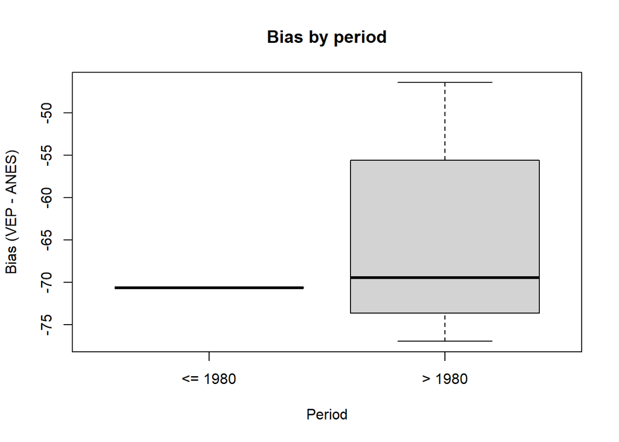

```r
# (3) Compare periods using a boxplot
boxplot(diff_vep_anes ~ period, data = turnout,
        xlab = "Period",
        ylab = "Bias (VEP - ANES)",
        main = "Bias by period")
```

```r
# (4) Same pattern for presidential vs midterm?
bias_by_period_and_type <- tapply(turnout$diff_vep_anes, list(turnout$period, turnout$election_type), mean, na.rm = TRUE)
bias_by_period_and_type
```

```
##           midterm presidential
## <= 1980        NA    -70.65804
## > 1980  -54.65429    -73.69476
```

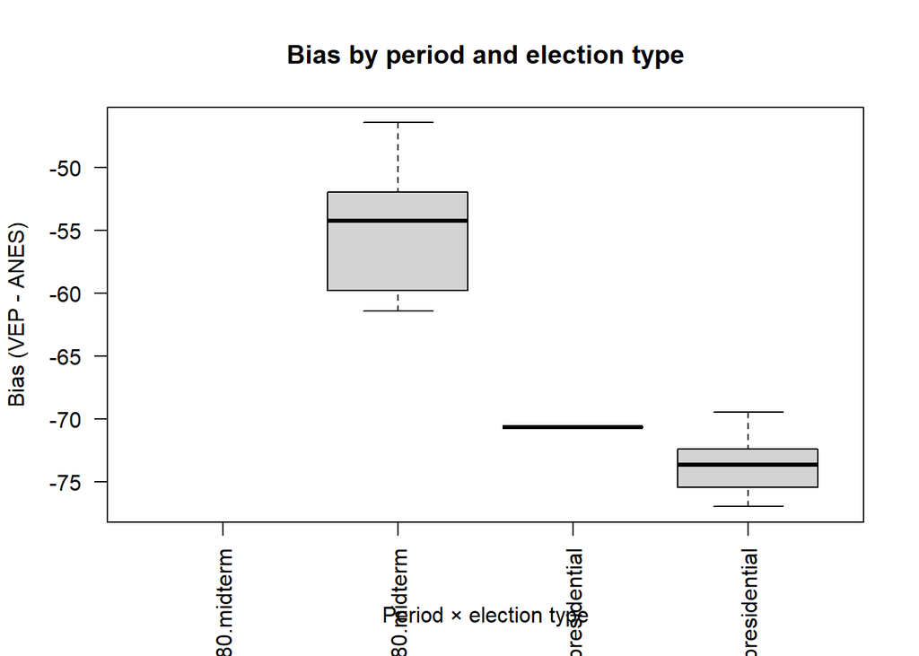

```r
boxplot(diff_vep_anes ~ interaction(period, election_type), data = turnout,
        las = 2,
        xlab = "Period × election type",
        ylab = "Bias (VEP - ANES)",
        main = "Bias by period and election type")
```

## Exercise 6 — Adjusted VAP turnout rate (2008)

**Tasks/Questions (year 2008 only):**

1. `adj_vap = VAP - felons - noncit`
2. `adj_total = total - osvoters`
3. `adj_vap_turnout_2008 = adj_total / (adj_vap + overseas)`
4. Compare adjusted VAP turnout to unadjusted VAP turnout, VEP turnout, and ANES.
5. Briefly discuss.

```r
d2008 <- turnout[turnout$year == 2008, ]

# 1) Adjusted denominator (VAP)
adj_vap <- d2008$VAP - d2008$felons - d2008$noncit

# 2) Adjusted numerator (ballots)
adj_total <- d2008$total - d2008$osvoters

# 3) Adjusted VAP turnout (include eligible overseas in denominator)
adj_vap_turnout_2008 <- adj_total / (adj_vap + d2008$overseas)

# 4) Compare measures (all are turnout rates)
comparison_2008 <- data.frame(
  measure = c("VAP turnout (unadjusted)", "VAP turnout (adjusted)", "VEP turnout", "ANES turnout"),
  turnout_rate = c(d2008$vap_turnout, adj_vap_turnout_2008, d2008$vep_turnout, d2008$ANES)
)

comparison_2008
```

```
##                    measure turnout_rate
## 1 VAP turnout (unadjusted)    0.5567409
## 2   VAP turnout (adjusted)    0.6143306
## 3              VEP turnout    0.6155433
## 4             ANES turnout   77.6000000
```

**Takeaways (example):**

- In 2008, unadjusted VAP turnout ≈ **0.557** and adjusted VAP turnout ≈ **0.614**.
- In 2008, VEP turnout ≈ **0.616**, ANES ≈ **77.6**.

**Interpretation (example):**  
The adjustment changes the denominator (removing ineligible groups) and changes the numerator (removing overseas ballots counted in `total`). If ANES is still noticeably higher than adjusted administrative turnout, that is consistent with some overreporting (or differences in survey coverage).

# Conclusions

- Administrative turnout rates (VAP/VEP-based) and survey turnout (ANES) can differ.
- Looking at bias by election type and over time helps us understand whether the pattern is stable or changing.

# Submission checklist

- ✅ `your_file.Rmd`
- ✅ `your_file.html` (compiled output)